# STAT 516 Lec 12

Logistic regression

Karl Gregory

2026-10-26

# Programming task data from Kutner et al. (2005)

Twenty-five people succeeded or failed at a programming task.

Months of programming experience was recorded for each person.

```r
experience <- c(14,29,6,25,18,4,18,12,22,6,30,11,30,5,20,13,9,32,24,13,19,4,28,22,8)
success <- c(0,0,0,1,1,0,0,0,1,0,1,0,1,0,1,0,0,1,0,1,0,0,1,1,1)
```

Can we predict probability of success based on experience?

# Programming task

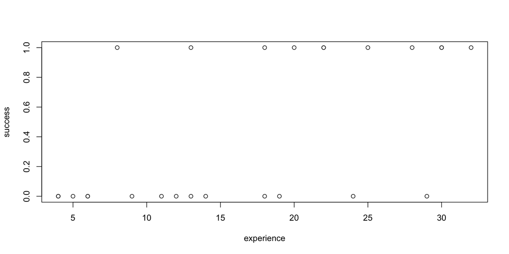

```r
plot(success ~ experience)
```

# Logistic regression model

Assume
$$Y_i \sim \text{Bernoulli}(\pi_i), \quad \log\left(\frac{\pi_i}{1-\pi_i}\right) = \beta_0 + \beta_1 x_i,$$
for $i =1,\dots,n$, where

- $Y_i$ is the response for observation $i$.
- $x_i$ is the value of a predictor/covariate/explanatory variable for obs $i$.
- $\pi_i$ is the probability of “success” for observation $i$.
- $\beta_0$ and $\beta_1$ are slope and intercept parameters.
- $\pi_i/ (1-\pi_i)$ is the odds of “success” for obs $i$.
- $\log(\pi_i/(1-\pi_i))$ is the log-odds for obs $i$.

Logistic regression assumes the log-odds are linear in the predictor.

# Odds

[figure not shown]

- Let $\pi$ be the probability of success.
- Then $\pi/(1-\pi)$ is called the odds in favor of success.
  1. If $\pi = 1/2$ then $\pi/(1-\pi) = 1$. “One-to-one” odds of success.
  2. If $\pi = 2/3$ then $\pi/(1-\pi) = 2$. Success 2x more likely than failure.
  3. If $\pi = 1/4$ then $\pi/(1-\pi) = 1/3$. Failure 3x more likely than success.

# The logit and logistic transformations

- The transformation $y = \frac{e^x}{1 +e^x}$ is called the logistic transformation.
- Its inverse $x = \log(\frac{y}{1-y})$ is called the logit transformation.
- We have
  $$\log\left(\frac{\pi_i}{1-\pi_i}\right) = \beta_0 + \beta_1 x_i \iff \pi_i = \frac{e^{\beta_0 + \beta_1 x_i}}{1 + e^{\beta_0 + \beta_1 x_i}}$$

# The logit and logistic transformations

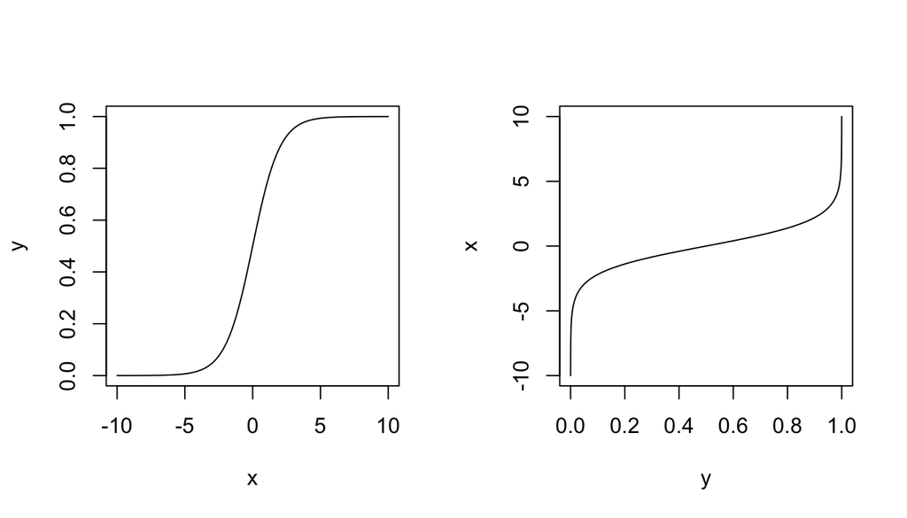

```r
x <- seq(-10,10,length=200)
y <- exp(x) / (1 + exp(x))
par(mfrow= c(1,2))
plot(y~x,type = "l")
plot(x~y,type = "l")
```

# Goals in logistic regression

1. Estimate $\beta_0$ and $\beta_1$.
2. Obtain fitted probabilities $\hat \pi_1,\dots,\hat \pi_n$.
3. Build CI for $\beta_1$ and test $H_0$: $\beta_1 = 0$.
4. Give interpretations of the estimated regression coefficients.
5. Check goodness of fit of the logistic regression model.
6. Add additional covariates

# Maximum likelihood estimation in logistic regression

- We do not use least-squares to estimate $\beta_0$ and $\beta_1$.
- Instead we use maximum likelihood estimators (MLEs).
- The MLEs are the parameter values giving the observed data the highest possible probability.
- Intercept $b_0$ and slope $b_1$ give to the observed data the probability
  $$\mathcal{L}_n(b_0,b_1) = \prod_{i=1}^n [\pi_i(b_0,b_1)]^{Y_i}[1-\pi_i(b_0,b_1)]^{1-Y_i}$$
  with $\displaystyle\pi_i(b_0,b_1) = \frac{e^{b_0 + b_1 x_i}}{1 + e^{b_0 + b_1 x_i}}$ for $i = 1,\dots,n$.
- The MLEs $\hat \beta_0$, $\hat \beta_1$ are the values of $b_0$, $b_1$ that maximize $\mathcal{L}_n(b_0,b_1)$.
- $\mathcal{L}_n(b_0,b_1)$ is called the likelihood function.

# Computing the MLEs in logistic regression

- There is no “closed-form” expression for $\hat \beta_0$ and $\hat \beta_1$.
- One must find their values numerically, that is with an algorithm.
- More convenient to work with $\log \mathcal{L}_n(b_0,b_1)$, which is given by
  $$\ell_n(b_0,b_1) = \sum_{i=1}^n[Y_i(b_0 + b_1 x_i) - \log(1 + e^{b_0 + b_1 x_i})].$$
- Newton’s method is one way to find the maximizers of $\ell_n(b_0,b_1)$.

# Programming task

Newton-Raphson algorithm for computing $\hat \beta_0$ and $\hat \beta_1$.

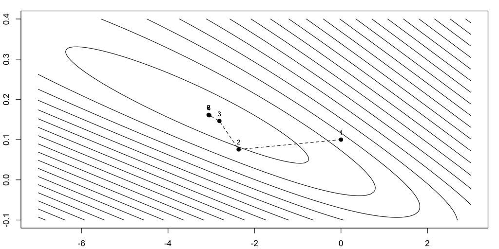

# Generalized linear models

- The logistic regression model is in a class of models called GLMs.
- GLM stands for generalized linear model.
- Poisson regression, binomial response regression, i.a. are GLMs too.
- Use `glm()` function in R to obtain $\hat \beta_0$ and $\hat \beta_1$.

# Programming task

Use `glm()` function with the option `family = "binomial"`.

```r
glm_out <- glm(success ~ experience, family = "binomial")
summary(glm_out)
```

```
Call:
glm(formula = success ~ experience, family = "binomial")

Coefficients:
            Estimate Std. Error z value Pr(>|z|)
(Intercept)   -3.060      1.259   -2.43    0.015 *
experience     0.162      0.065    2.49    0.013 *
---
Signif. codes:  0 '***' 0.001 '**' 0.01 '*' 0.05 '.' 0.1 ' ' 1

(Dispersion parameter for binomial family taken to be 1)

    Null deviance: 34.296  on 24  degrees of freedom
Residual deviance: 25.425  on 23  degrees of freedom
AIC: 29.42

Number of Fisher Scoring iterations: 4
```

# Programming task

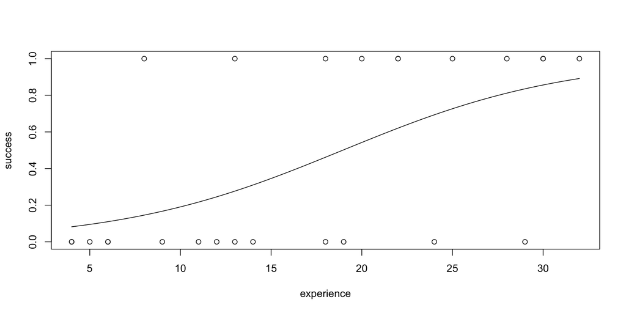

```r
x <- seq(min(experience),max(experience),length = 200)
pihat_x <- 1/(1 + exp( -(coef(glm_out)[1] + coef(glm_out)[2]*x)))
plot(success ~ experience); lines(pihat_x~x)
```

# Fitted probabilities

- Define the fitted probabilities as
  $$\hat \pi_i = \dfrac{e^{\hat \beta_0 + \hat \beta_1 x_i}}{1 + e^{\hat \beta_0 + \hat\beta_1 x_i}} \quad \text{ for } \quad i = 1,\dots,n.$$
- For any value $x_{\operatorname{new}}$, we estimate the probability of “success” as
  $$\hat\pi_{\operatorname{new}} =\dfrac{e^{\hat \beta_0 + \hat \beta_1 x_{\operatorname{new}}}}{1 + e^{\hat \beta_0 + \hat\beta_1 x_{\operatorname{new}}}}.$$

# Programming task

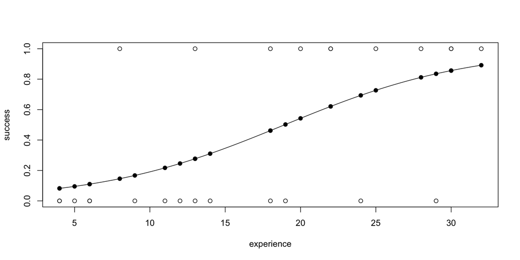

```r
plot(success ~ experience); lines(pihat_x~x)
points(glm_out$fitted.values~experience,pch = 19)
```

# Asymptotic distribution of slope estimator and CI

- For large enough $n$, $\hat \beta_1$ is approximately Normal, such that
  $$\frac{\hat \beta_1 - \beta_1}{\widehat{\operatorname{se}}\{\hat\beta_1\}} \overset{\operatorname{approx}}{\sim} \text{Normal}\left(0,1\right),$$
  where, setting $\hat w_i = \hat \pi_i(1-\hat\pi_i)$ for $i = 1,\dots,n$, we may write
  $$\widehat{\operatorname{se}}\{\hat\beta_1\} = \textstyle \left[\sum_{i=1}^n \hat w_ix_i^2 - (\sum_{i=1}^n \hat w_i)^{-1}(\sum_{i=1}^n \hat w_i x_i)^2\right]^{-\frac{1}{2}}.$$
- We can make an approximate $(1-\alpha)100\%$ CI for $\beta_1$ as
  $$\hat \beta_1 \pm z_{\alpha/2} ~ \widehat{\operatorname{se}}\{\hat\beta_1\}.$$

# Programming task

```r
# Confidence interval for beta1
pihat <- glm_out$fitted.values
b1hat <- coef(glm_out)[2]
w <- pihat*(1-pihat)
se <- sqrt(1/(sum(w*experience^2) - sum(w*experience)^2/sum(w)))
lo <- b1hat - 1.96 * se
up <- b1hat + 1.96 * se
c(lo,up)
```

```
experience experience
    0.0341     0.2888
```

```r
# CIs for both beta0 and beta1 automatically from glm_out
confint.default(glm_out)
```

```
              2.5 % 97.5 %
(Intercept) -5.5280 -0.591
experience   0.0341  0.289
```

# Testing whether the slope coefficient is zero

The `summary()` function on the `glm()` output prints this p value.

# Odds ratios

- Let $\pi_0$ and $\pi_1$ be success probs under an initial and an altered condition, respectively.
- Then we call the ratio
  $$\displaystyle \frac{\pi_1/(1-\pi_1)}{\pi_0/(1-\pi_0)}$$
  the odds ratio associated with the change from the initial to the altered condition.
- The odds ratio is the factor by which the odds are multiplied when the initial condition is changed to the altered condition.

# Interpreting the logistic regression parameters

- Let $\pi_0$ and $\pi_1$ be the “success” probabilities at $x_0$ and $x_0 + 1$.
- Then we have the two equations
  1. $\log\left(\frac{\pi_0}{1-\pi_0}\right) = \beta_0 + \beta_1 x_0$
  2. $\log\left(\frac{\pi_1}{1-\pi_1}\right) = \beta_0 + \beta_1 (x_0 + 1)$
- Subtracting the first equation from the second gives
  $$\beta_1 = \log\left(\frac{\pi_1}{1-\pi_1}\right) - \log\left(\frac{\pi_0}{1-\pi_0}\right) = \log\left(\frac{\pi_1/(1-\pi_1)}{\pi_0/(1-\pi_0)}\right).$$
- The quantity $\dfrac{\pi_1/(1-\pi_1)}{\pi_0/(1-\pi_0)}$ is called an odds ratio.
- So $\beta_1$ is log of the odds ratio associated with a unit increase in $x$.

# Odds ratio from a unit increase in x

- From the previous slide, we have
  $$e^{\beta_1} = \frac{\pi_1/(1-\pi_1)}{\pi_0/(1-\pi_0)}.$$
- Can build a CI for $e^{\beta_1}$ by exponentiating the CI for $\beta_1$.
- Gives CI for $e^{\beta_1}$ as $[e^{\hat \beta_1 - z_{\alpha/2}\widehat{\operatorname{se}}\{\hat\beta_1\}},e^{\hat \beta_1 + z_{\alpha/2}\widehat{\operatorname{se}}\{\hat\beta_1\}}]$.
- A unit increase in $x$ multiplies the odds of success by the factor $e^{\beta_1}$.
- What if the CI for $e^{\beta_1}$ contains $1$?

# Programming task

```r
exp(confint.default(glm_out,parm = "experience"))
```

```
           2.5 % 97.5 %
experience  1.03   1.33
```

Each additional month of experience increases the odds of completing the programming task by a factor of 1.035 to 1.335, with $95\%$ confidence.

# Residuals for logistic regression

- Ordinary residuals $Y_i - \hat \pi_i$ cannot be Normally distributed.
- In GLMs, one looks at special residuals called deviance residuals.
- In logistic regression, the deviance residuals are defined as
  $$\hat d_i = \operatorname{sign}(Y_i - \hat \pi_i)\sqrt{-2[Y_i\log \hat \pi_i + (1- Y_i)\log(1 - \hat \pi_i)]}$$
  for $i=1,\dots,n$.
- These are not Normal either, but are useful for assessing model fit.

# Programming task

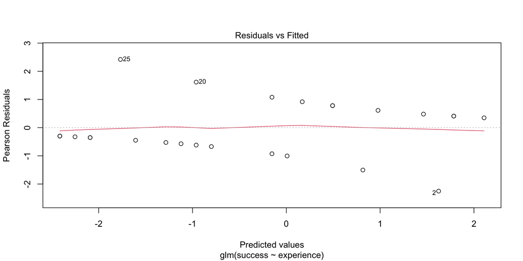

```r
plot(glm_out,which = 1)
```

# Checking model fit with a simulated envelope

The simulated envelope method is described in Kutner et al. (2005):

- Fit the logistic regression model and obtain $\hat \pi_1,\dots,\hat \pi_n$.
- Obtain the deviance residuals; sort them as $\hat d_{(1)} < \hat d_{(2)} < \dots <\hat d_{(n)}$.
- Generate many new data sets $Y_i^* \sim \text{Bernoulli}(\hat \pi_i)$, $i=1,\dots,n$.
- For each new data set, obtain sorted $\hat d_{(1)}^* < \hat d_{(2)}^* < \dots <\hat d_{(n)}^*$.
- Plot $\hat d_{(i)}$ as well as the 0.025 and 0.975 quantiles and the mean of the $\hat d_{(i)}^*$ $\forall ~i$ (it doesn’t matter what is chosen as the $x$-axis).
- The quantiles of the $\hat d_{(i)}^*$ make a band. If the model fits, then the $\hat d_{(i)}$ should lie within the band and close to the mean.

Asks: If the model is correct, how would the deviance residuals behave?

# Programming task

```r
library(glmtoolbox) # first time run install.packages("glmtoolbox")
envelope(glm_out,type = "deviance")
```

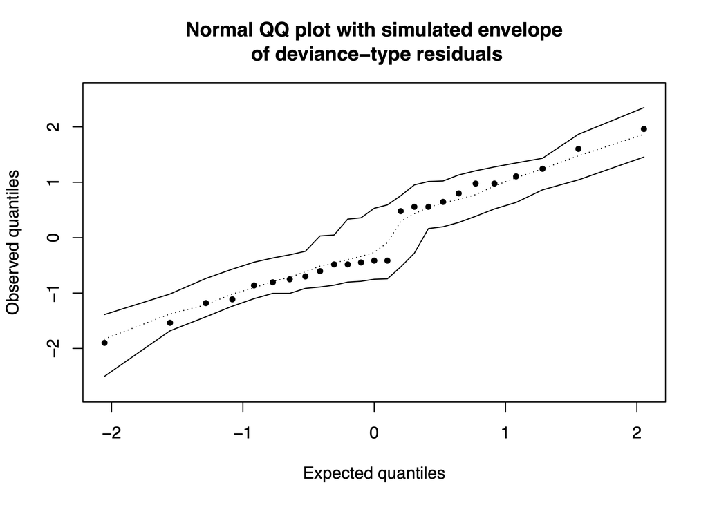

# Programming task

```r
experience2 <- (experience - mean(experience))^2
envelope(glm(success ~ experience2, family = "binomial"),type = "deviance")
```

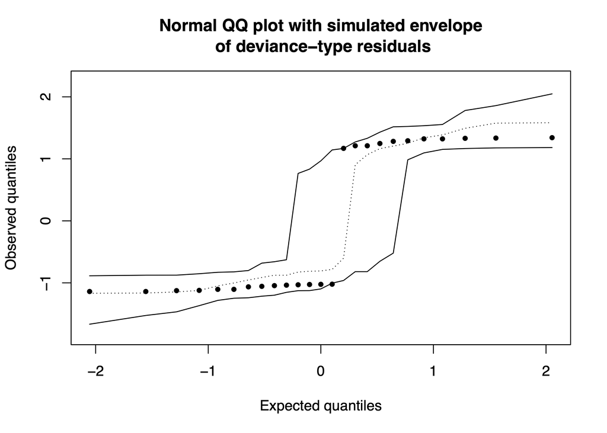

# German credit score data from Hofmann (1994)

Response is credit rating (good/bad), various predictors.

```r
library(foreign) # credit-g dataset from https://www.openml.org/
link <- url("https://people.stat.sc.edu/gregorkb/data/dataset_31_credit-g.arff")
credg <- read.arff(link)
colnames(credg)
```

```
 [1] "checking_status"        "duration"               "credit_history"
 [4] "purpose"                "credit_amount"          "savings_status"
 [7] "employment"             "installment_commitment" "personal_status"
[10] "other_parties"          "residence_since"        "property_magnitude"
[13] "age"                    "other_payment_plans"    "housing"
[16] "existing_credits"       "job"                    "num_dependents"
[19] "own_telephone"          "foreign_worker"         "class"
```

# German credit score

```r
summary(credg[,1:3])
```

```
    checking_status    duration                           credit_history
 <0         :274    Min.   : 4.0   all paid                      : 49
 >=200      : 63    1st Qu.:12.0   critical/other existing credit:293
 0<=X<200   :269    Median :18.0   delayed previously            : 88
 no checking:394    Mean   :20.9   existing paid                 :530
                    3rd Qu.:24.0   no credits/all paid           : 40
                    Max.   :72.0
```

# Logistic multiple regression model

Observe $(\mathbf{x}_1,Y_1),\dots,(\mathbf{x}_n,Y_n)$, $\mathbf{x}_i = (x_{i1},\dots,x_{ip})^T$ and assume
$$Y_i \sim \text{Bernoulli}(\pi_i), \quad \log\left(\frac{\pi_i}{1-\pi_i}\right) = \beta_0 + \beta_1 x_{i1} + \dots + \beta_p x_{ip},$$
for $i =1,\dots,n$, where

- $Y_i$ is the response for observation $i$.
- $x_{i1},\dots,x_{ip}$ are the values of the predictors for obs $i$.
- $\pi_i$ is the probability of “success” for observation $i$.
- $\beta_0$ is an intercept and $\beta_1,\dots,\beta_p$ are slope parameters.
- $\pi_i/ (1-\pi_i)$ is the odds of “success” for obs $i$.
- $\log(\pi_i/(1-\pi_i))$ is the log-odds for obs $i$.

So we assume the log-odds are a linear function of the predictors.

# Interpreting multiple logistic regression parameters

- Let $\pi_{0j}$ and $\pi_{1j}$ be the “success” probabilities at $x_{0j}$ and $x_{0j}+1$ but with $x_{0k}$ fixed for all $k \neq j$.
- Then we have the two equations
  1. $\log\left(\frac{\pi_{0j}}{1-\pi_{0j}}\right) = \beta_0 + \sum_{k \neq j}\beta_k x_{0k} + \beta_j x_{0j}$
  2. $\log\left(\frac{\pi_{1j}}{1-\pi_{1j}}\right) = \beta_0 + \sum_{k\neq j}\beta_k x_{0k} + \beta_j(x_{0j} + 1)$
- Subtracting the first equation from the second gives
  $$\beta_j = \log\left(\frac{\pi_{1j}/(1-\pi_{1j})}{\pi_{0j}/(1-\pi_{0j})}\right) \quad \text{ and } \quad e^{\beta_j} = \frac{\pi_{1j}/(1-\pi_{1j})}{\pi_{0j}/(1-\pi_{0j})}.$$
- So $\beta_1$ is log of the odds ratio associated with a unit increase in $x_j$ with all other predictors held fixed.

# German credit score

```r
glm_out <- glm(class ~ ., family = "binomial", data = credg)
summary(glm_out)
```

```
Call:
glm(formula = class ~ ., family = "binomial", data = credg)

Coefficients:
                                              Estimate Std. Error z value Pr(>|z|)
(Intercept)                                   1.50e+00   1.25e+00    1.21  0.22780
checking_status>=200                          9.66e-01   3.69e-01    2.62  0.00890 **
checking_status0<=X<200                       3.75e-01   2.18e-01    1.72  0.08540 .
checking_statusno checking                    1.71e+00   2.32e-01    7.37  1.7e-13 ***
duration                                     -2.79e-02   9.30e-03   -3.00  0.00272 **
credit_historycritical/other existing credit  1.58e+00   4.38e-01    3.60  0.00031 ***
credit_historydelayed previously              9.97e-01   4.70e-01    2.12  0.03410 *
credit_historyexisting paid                   7.29e-01   3.85e-01    1.89  0.05824 .
credit_historyno credits/all paid             1.43e-01   5.49e-01    0.26  0.79392
purposedomestic appliance                    -2.17e-01   8.04e-01   -0.27  0.78698
purposeeducation                             -7.76e-01   4.66e-01   -1.67  0.09572 .
purposefurniture/equipment                    5.15e-02   3.54e-01    0.15  0.88439
purposenew car                               -7.40e-01   3.34e-01   -2.22  0.02667 *
purposeother                                  7.49e-01   8.00e-01    0.94  0.34920
purposeradio/tv                               1.51e-01   3.37e-01    0.45  0.65300
purposerepairs                               -5.24e-01   5.93e-01   -0.88  0.37743
purposeretraining                             1.32e+00   1.23e+00    1.07  0.28462
purposeused car                               9.26e-01   4.41e-01    2.10  0.03564 *
credit_amount                                -1.28e-04   4.44e-05   -2.89  0.00389 **
savings_status>=1000                          1.34e+00   5.25e-01    2.55  0.01073 *
savings_status100<=X<500                      3.58e-01   2.86e-01    1.25  0.21113
savings_status500<=X<1000                     3.76e-01   4.01e-01    0.94  0.34848
savings_statusno known savings                9.47e-01   2.62e-01    3.61  0.00031 ***
employment>=7                                 2.10e-01   2.95e-01    0.71  0.47672
employment1<=X<4                              1.16e-01   2.42e-01    0.48  0.63242
employment4<=X<7                              7.64e-01   3.05e-01    2.50  0.01227 *
employmentunemployed                         -6.69e-02   4.27e-01   -0.16  0.87548
installment_commitment                       -3.30e-01   8.83e-02   -3.74  0.00018 ***
personal_statusmale div/sep                  -2.75e-01   3.87e-01   -0.71  0.47604
personal_statusmale mar/wid                   9.16e-02   3.12e-01    0.29  0.76891
personal_statusmale single                    5.41e-01   2.10e-01    2.57  0.01011 *
other_partiesguarantor                        1.41e+00   5.69e-01    2.49  0.01283 *
other_partiesnone                             4.36e-01   4.10e-01    1.06  0.28770
residence_since                              -4.78e-03   8.64e-02   -0.06  0.95592
property_magnitudelife insurance             -8.69e-02   2.31e-01   -0.38  0.70711
```

[output cut: 9 more lines]

```
jobunemp/unskilled non res                    4.79e-01   6.62e-01    0.72  0.46909
jobunskilled resident                        -5.67e-02   3.50e-01   -0.16  0.87145
num_dependents                               -2.65e-01   2.49e-01   -1.06  0.28825
own_telephoneyes                              3.00e-01   2.01e-01    1.49  0.13606
foreign_workeryes                            -1.39e+00   6.26e-01   -2.22  0.02609 *
---
Signif. codes:  0 '***' 0.001 '**' 0.01 '*' 0.05 '.' 0.1 ' ' 1

(Dispersion parameter for binomial family taken to be 1)

    Null deviance: 1221.73  on 999  degrees of freedom
Residual deviance:  895.82  on 951  degrees of freedom
AIC: 993.8

Number of Fisher Scoring iterations: 5
```

# German credit score

Note that `glm()` estimates three coefficients for `checking_status`.

```r
summary(credg$checking_status)
```

```
         <0       >=200    0<=X<200 no checking
        274          63         269         394
```

Numeric predictors to encode the levels of the categorical predictor:
$$\begin{align*}
x_{i1} &= \left\{\begin{array}{ll}
1& 200 \leq \texttt{checking}\\
0& \text{otherwise}\end{array}\right. \\
x_{i2} &= \left\{\begin{array}{ll}
1& 0 \leq \texttt{checking} <200 \\
0& \text{otherwise}\end{array}\right.\\
x_{i3} &= \left\{\begin{array}{ll}
1& \texttt{no checking}\\
0& \text{otherwise}\end{array}\right.
\end{align*}$$

Likewise for other categorical predictors.

# Deviances replace error sums of squares in GLMs

- The deviance is the sum of squared *deviance* residuals $\sum_{i=1}^n \hat d_i^2$ .
- In logistic regression the deviance can be computed as
  $$\operatorname{Dev} = -2\sum_{i=1}^n[Y_i \log \hat \pi_i + (1 - Y_i) \log(1 - \hat \pi_i)].$$
- Full-reduced model test: Reject $H_0$: $\beta_j = 0$ for all $j \in D$ if
  $$\operatorname{Dev}(\operatorname{Reduced}) - \operatorname{Dev}(\operatorname{Full}) > \chi_{s,\alpha}^2,$$
  where $s$ is the number of predictors in $D$ (need large $n$).

# German credit score

Test whether any level of checking status is important to the credit score.

```r
credg_red <- credg[,-1] # remove checking_status column

glm_full <- glm(class ~ ., family = "binomial", data = credg)
glm_red <-  glm(class ~ ., family = "binomial", data = credg_red)

p <- length(coef(glm_full)) - 1
s <- nlevels(credg$checking_status) - 1

1 - pchisq(glm_red$deviance - glm_full$deviance,s)
```

```
[1] 2.73e-14
```

# Variable selection in logistic regression

- We may want to discard some of our predictors.
- One way is to add/remove variables stepwise according to AIC.
- Can do this just as we did in multiple linear regression.
- Be cautious about making inferences after selecting a model.

# German credit score

```r
glm_all <- glm(class ~ ., family = "binomial", data = credg)
step_back <- step(glm_all,
                  direction = "backward",
                  scope = formula(glm_all),
                  criterion = "aic",
                  trace = 0) # suppress printed output
summary(step_back)
```

```
Call:
glm(formula = class ~ checking_status + duration + credit_history +
    purpose + credit_amount + savings_status + installment_commitment +
    personal_status + other_parties + age + other_payment_plans +
    housing + own_telephone + foreign_worker, family = "binomial",
    data = credg)

Coefficients:
                                              Estimate Std. Error z value Pr(>|z|)
(Intercept)                                   4.84e-01   1.02e+00    0.48  0.63436
checking_status>=200                          1.02e+00   3.63e-01    2.82  0.00474 **
checking_status0<=X<200                       3.90e-01   2.12e-01    1.84  0.06593 .
checking_statusno checking                    1.72e+00   2.28e-01    7.53    5e-14 ***
duration                                     -2.57e-02   8.94e-03   -2.87  0.00407 **
credit_historycritical/other existing credit  1.37e+00   4.04e-01    3.40  0.00068 ***
credit_historydelayed previously              7.91e-01   4.49e-01    1.76  0.07799 .
credit_historyexisting paid                   7.12e-01   3.79e-01    1.88  0.06030 .
credit_historyno credits/all paid            -1.19e-01   5.27e-01   -0.23  0.82161
purposedomestic appliance                    -2.58e-01   7.76e-01   -0.33  0.74004
purposeeducation                             -9.26e-01   4.57e-01   -2.03  0.04263 *
purposefurniture/equipment                   -4.22e-02   3.42e-01   -0.12  0.90175
purposenew car                               -7.83e-01   3.27e-01   -2.39  0.01675 *
purposeother                                  6.52e-01   7.83e-01    0.83  0.40495
purposeradio/tv                               1.37e-01   3.29e-01    0.42  0.67733
purposerepairs                               -6.40e-01   5.81e-01   -1.10  0.27036
purposeretraining                             1.38e+00   1.24e+00    1.11  0.26523
purposeused car                               8.25e-01   4.29e-01    1.92  0.05449 .
credit_amount                                -1.29e-04   4.22e-05   -3.07  0.00217 **
savings_status>=1000                          1.29e+00   5.07e-01    2.54  0.01101 *
savings_status100<=X<500                      3.28e-01   2.77e-01    1.19  0.23548
savings_status500<=X<1000                     4.30e-01   3.93e-01    1.09  0.27390
savings_statusno known savings                9.63e-01   2.57e-01    3.75  0.00018 ***
installment_commitment                       -3.30e-01   8.55e-02   -3.86  0.00011 ***
personal_statusmale div/sep                  -2.87e-01   3.76e-01   -0.76  0.44533
personal_statusmale mar/wid                   1.30e-01   3.06e-01    0.42  0.67180
personal_statusmale single                    5.36e-01   1.97e-01    2.71  0.00669 **
other_partiesguarantor                        1.53e+00   5.58e-01    2.74  0.00619 **
other_partiesnone                             4.87e-01   4.00e-01    1.22  0.22265
age                                           1.31e-02   8.40e-03    1.56  0.11897
other_payment_plansnone                       6.99e-01   2.35e-01    2.98  0.00292 **
other_payment_plansstores                     7.86e-02   4.03e-01    0.19  0.84539
housingown                                    2.92e-01   2.89e-01    1.01  0.31213
housingrent                                  -1.50e-01   3.41e-01   -0.44  0.66079
own_telephoneyes                              2.79e-01   1.84e-01    1.52  0.12939
foreign_workeryes                            -1.38e+00   6.21e-01   -2.23  0.02593 *
---
Signif. codes:  0 '***' 0.001 '**' 0.01 '*' 0.05 '.' 0.1 ' ' 1

(Dispersion parameter for binomial family taken to be 1)

    Null deviance: 1221.7  on 999  degrees of freedom
Residual deviance:  910.5  on 964  degrees of freedom
AIC: 982.5

Number of Fisher Scoring iterations: 5
```

# German credit score

```r
envelope(step_back,type="deviance")
```

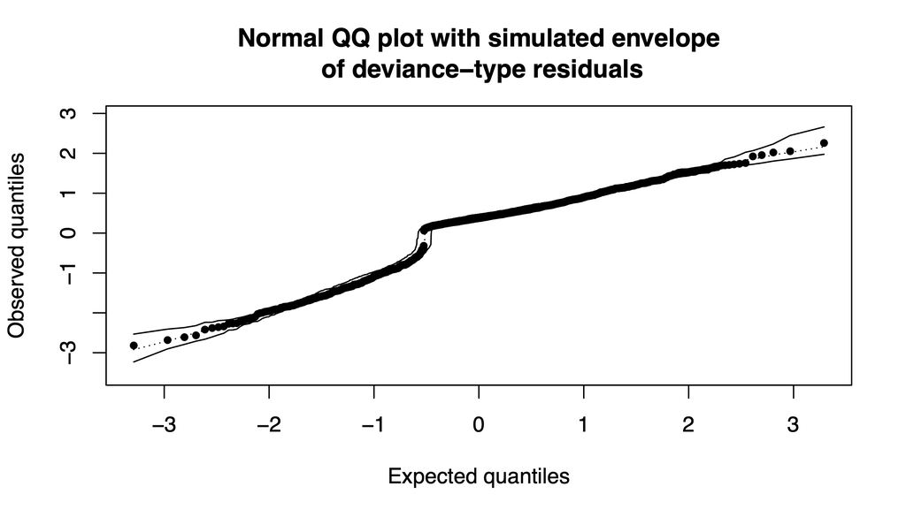

# Classification with the logistic regression model

Consider classifying the observations as 1 or 0 according to $\hat \pi_i$:

- Choose a threshold $c \in [0,1]$ and make the classification
  $$\hat Y_i = \left\{ \begin{array}{ll}
  1,& \hat \pi_i \geq c\\
  0,& \hat \pi_i < c.
  \end{array}\right.$$
- Can compute misclassification rate $\#\{\hat Y_i \neq Y_i\}/n$.
- Can compute observed true positive and false positive rates
  $$\text{TP} = \frac{\#\{\hat Y_i = 1 \cap Y_i = 1\}}{\#\{Y_i = 1\}} \quad \text{ and } \quad
  \text{FP} = \frac{\#\{\hat Y_i = 1 \cap Y_i = 0\}}{\#\{Y_i = 0\}}.$$
- Plotting TP against FP over all $c \in [0,1]$ creates the receiver operating characteristic (ROC) curve.

# German credit score

Compute TP and FP over a range of thresholds $c$. Plot ROC curve.

```r
Y <- ifelse(credg$class == "good",1,0)
pi_hat <- step_back$fitted.values

n1 <- sum(Y == 1)
n0 <- sum(Y == 0)

cc <- sort(c(0,pi_hat,1))
TP <- FP <- numeric(length(cc))
for(j in 1:length(cc)){

  Yhat <- pi_hat >= cc[j]
  TP[j] <- sum(Yhat == 1 & Y == 1) / n1
  FP[j] <- sum(Yhat == 1 & Y == 0) / n0

}
```

# German credit score

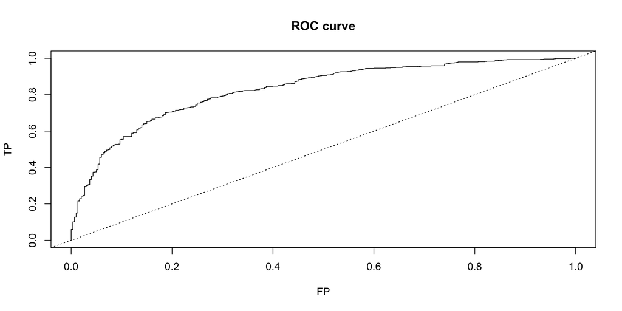

```r
plot(TP ~ FP, type = "l", main = "ROC curve")
abline(0,1,lty = 3)
```

# German credit score

Can use ROC curves to compare models.

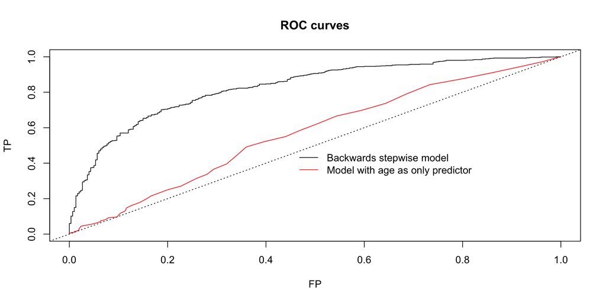

# Traning and testing data sets

- Overfitting is fitting a model such that it performs well on the data used to fit it, but will perform poorly when it is given new data.
- To avoid, split data into training and testing data sets
  $$\{(\mathbf{x}_i^{\text{train}},Y_i^{\text{train}})\}_{i \in \mathcal{I}_{\text{train}}} \quad \text{ and } \quad \{(\mathbf{x}_i^{\text{test}},Y_i^{\text{test}})\}_{i \in \mathcal{I}_{\text{test}}},$$
  where $\mathcal{I}_{\text{train}} \cap \mathcal{I}_{\text{test}} = \emptyset$ and $\mathcal{I}_{\text{train}} \cup \mathcal{I}_{\text{test}} = \{1,\dots,n\}$.
- Fit models on training data. Compare performance on testing data.
- For example, compute misclassification rate or draw ROC curve for testing data.

# German credit score

```r
set.seed(1)
n <- nrow(credg)
n_train <- ceiling(.5*n)
n_test <- n - n_train
ind_train <- sample(n,n_train) # randomly select a training set

credg_train <- credg[ind_train,]
credg_test <- credg[-ind_train,]

glm_train <- glm(class ~ ., family = "binomial", data = credg_train)

ypred_train <- glm_train$fitted.values >= 0.5
y_train <- as.numeric(credg_train$class == "good")
misclass_train <- mean(ypred_train != y_train)
misclass_train
```

```
[1] 0.204
```

```r
pihat_test <- predict(glm_train,newdata = credg_test,type="response")

ypred_test <- pihat_test >= 0.5
y_test <- as.numeric(credg_test$class == "good")

misclass_test <- mean(ypred_test != y_test)
misclass_test
```

```
[1] 0.258
```

# References

Hofmann, Hans. 1994. “Statlog (German Credit Data).” UCI Machine Learning Repository.

Kutner, Michael H, Christopher J Nachtsheim, John Neter, and William Li. 2005. *Applied Linear Statistical Models*. McGraw-hill.